# AlphaSimR: Base population and traits

Marco Antonio Peixoto, [^1]

## Introduction

To start a set of simulations in the `AlphaSimR` package (Gaynor, Gorjanc, and Hickey 2021), four steps must be implemented, as follows:

1. Simulate founder genomes/haplotypes.
2. Set global simulation parameters for a target trait/traits.
3. Model the breeding program.
4. Examine results by looking into population individuals’ metrics.

In this vignette, we will implement and further explore the first two.

## Genetic basis of base population: Founder genomes

First, we clean our working environment and download/load the AlphaSimR package.

```r
#install.packages('AlphaSimR')
require(AlphaSimR)
```

To create the founder genome we may use the function `runMacs()`. It uses the method from Chen et al. (Chen, Marjoram, and Wall 2009) to simulate a set of haplotypes and, from that, a species-specific demography. This allows us to simulate a base genome with characteristics of the target crop that we are working with.

```r
# Founder genome
founderGenomes = runMacs(nInd = 10, # Number of individuals that compose the base genome
                         nChr = 10, # Number of chromosome pairs of the target species
                         segSites = 100, # number of segregation sites
                         species = "MAIZE", # We can use the base parameters and we have available in the package MAIZE, WHEAT, CATTLE, and GENERIC.
                         ploidy = 2) # Setting the ploidy


# Object created
founderGenomes
```

```
## An object of class "MapPop"
## Ploidy: 2
## Individuals: 10
## Chromosomes: 10
## Loci: 1000
```

```r
# Genetic map of the segregation sites
founderGenomes@genMap
```

[output not shown]

[output cut: 288 more lines]

[output not shown]

When we choose the species in the argument *species*, four parameters are automatically adjusted:

```r
# Genome length (i.e. Soybean)
genLen = 1.15 #Gb

# Effective population size (Ne)
Ne = 50

# Demographic bottlenecks
speciesParams = "8E8 -t 4E-7 -r 3.6E-7"

# Species history
speciesHist = "-eN 0.03 1 -eN 0.05 2 -eN 0.10 4 -eN 0.15 6"
```

**Obs**: `runMacs()` functions offers four target species with their demography already implemented in the package. Other than that, we can use `runMacs2()` function to set our own species characteristics (further discussed).

## Trait characteristics

With the founder genomes in perspective, we can proceed to add the characteristics of the target trait or traits to the simulation. **AlphaSimR** has a vignette that we recommend you take a look at [link](https://cran.r-project.org/web/packages/AlphaSimR/vignettes/traits.pdf). It gives, thoroughly, an explanation on the traits of interest and how to interpret its effects.

### Single trait

#### **Additive trait**

We will start with a trait with only additive effects. For such, we have the following parameters:

```r
# Global simulation parameters from founder genomes.
SP = SimParam$new(founderGenomes)

# Additive trait
SP$addTraitA(nQtlPerChr = 15, # Number of QTL per chromosome
             mean = 10, # Trait mean
             var = 10) # Trait variance


# QTL effects (for the traits)
SP$traits[[1]]@addEff
```

```
##   [1]  0.085565946 -0.437593711  0.203398614 -0.765935624 -0.032465806
##   [6]  0.044232110 -0.473991442  0.544934027  0.119530112 -0.529582836
##  [11] -0.022884257 -0.032665433  0.463425601  0.306441965 -0.597857746
##  [16]  0.089172636 -0.594680464 -0.289057561 -1.132172291  0.726862440
##  [21] -0.443075949 -0.461144414  0.552168175 -0.020827062  0.522046842
##  [26] -0.271751303 -0.488491217  0.614012446  0.190092664  0.613821052
##  [31] -0.251684523 -0.038784679  0.064384267 -0.348377377 -0.066404222
##  [36] -0.106181607  0.802525974  0.098876784 -0.550690863  0.368050133
##  [41]  0.392263954  0.194181205  0.000997263  0.765697273 -0.697251928
##  [46] -0.075129410 -0.476404145  0.279559984  0.014631521  0.444036629
##  [51] -0.198736165  0.282284217  0.059593793  0.345534932  0.410675627
##  [56]  0.113421759 -0.019799552  0.319209614  0.652818662 -0.173292126
##  [61] -0.305048432  0.268166932 -0.375904821  0.205511432 -0.393798529
##  [66] -0.719018698 -0.175972131 -0.611367498  0.295211059 -0.132458523
##  [71]  0.319610939  0.189503240 -0.418237422  0.031265120  0.478585516
##  [76]  0.542797551  0.128094071  0.675666650 -0.266860179 -0.360142214
##  [81]  0.171089204  0.411911604 -0.246958759 -0.249808741 -0.655187464
##  [86]  0.259031995 -0.275548182  0.985861993 -0.167418803  0.552554404
##  [91] -0.906867876 -0.729210088  0.834265758  0.250512213  0.285237244
##  [96] -0.494364824 -0.252733968 -0.138225223 -0.545484389 -0.763655225
## [101]  0.699225516  0.172230658  0.200142575 -0.720550657 -0.184802557
## [106] -0.128681837 -0.225803808 -0.248233156  0.443527370 -0.047819353
## [111]  0.505110753 -0.048570193  0.204505499  0.077362334  0.249524296
## [116]  0.627307116  0.257669585  0.296161206 -0.951309833  0.233852492
## [121]  0.511375231 -0.102660772 -0.112685449 -0.340946958  0.253392632
## [126] -0.280668491  0.842505754 -0.445981692 -0.230430235  0.642092669
## [131]  0.266243512  0.064713263 -0.009228176  0.136110239  0.316591631
## [136] -0.078515824 -0.305115080  0.874491147  0.336274870  0.177426467
## [141]  0.054279665 -0.738748878  0.324329287  0.434409559  0.067569063
## [146]  0.421375021  0.693381404  0.341151051  0.040458101  0.031176381
```

```r
SP$traits[[1]]@lociLoc
```

```
##   [1]   5   7   9  12  31  38  41  51  53  60  68  69  80  82  94   3  17  21
##  [19]  25  32  42  43  44  46  51  53  61  71  79  81   1   7  18  22  23  30
##  [37]  46  47  49  53  54  67  85  89 100   4   5  17  26  30  31  32  48  51
##  [55]  64  81  83  84  86  89  12  15  19  26  32  34  47  53  55  59  60  70
##  [73]  85  88  90   8  13  25  39  46  49  54  55  59  70  83  93  96  97 100
##  [91]   2   6  11  18  24  54  59  64  73  74  85  89  95  96  99   1   7   8
## [109]  13  18  26  30  32  42  60  75  78  80  84  92   4   7  19  28  34  43
## [127]  48  50  59  65  68  70  75  79  98  12  14  18  29  37  41  43  48  54
## [145]  59  62  64  80  97  99
```

After simulating the base genome and to set the trait characteristics, we can create individuals from that base genome for the trait of interest. We will use the function `newPop()`, as follows:

```r
# Creating individuals/population
basePop = newPop(founderGenomes)

# Gen param
genParam(basePop)
```

```
## $varA
##        Trait1
## Trait1     10
##
## $varD
##        Trait1
## Trait1      0
##
## $varAA
##        Trait1
## Trait1      0
##
## $varG
##        Trait1
## Trait1     10
##
## $genicVarA
##   Trait1
## 9.321657
##
## $genicVarD
## Trait1
##      0
##
## $genicVarAA
## Trait1
##      0
##
## $genicVarG
##   Trait1
## 9.321657
##
## $covA_HW
##    Trait1
## -1.069452
##
## $covD_HW
## Trait1
##      0
##
```

[output cut: 123 more lines]

```
##  [9,]      0
## [10,]      0
##
## $gv_aa
##       Trait1
##  [1,]      0
##  [2,]      0
##  [3,]      0
##  [4,]      0
##  [5,]      0
##  [6,]      0
##  [7,]      0
##  [8,]      0
##  [9,]      0
## [10,]      0
```

```r
# Looking at the population
# haplotypes
popHaplo = pullSegSiteHaplo(basePop)
popHaplo[, 1:10]
```

```
##      1_1 1_2 1_3 1_4 1_5 1_6 1_7 1_8 1_9 1_10
## 1_1    1   0   1   0   0   1   1   0   0    0
## 1_2    0   1   0   0   0   0   0   1   0    1
## 2_1    0   0   1   0   0   1   1   0   0    0
## 2_2    1   1   0   1   0   0   1   0   0    0
## 3_1    0   1   0   0   0   1   0   0   0    0
## 3_2    0   0   1   0   0   1   1   0   1    0
## 4_1    0   1   0   1   0   1   0   0   0    0
## 4_2    0   1   0   0   0   1   1   0   1    0
## 5_1    0   1   0   1   0   0   1   0   1    0
## 5_2    0   0   1   0   0   1   1   0   1    0
## 6_1    1   0   1   0   0   0   1   0   0    1
## 6_2    0   1   0   1   0   0   1   0   0    0
## 7_1    1   1   0   1   0   0   1   0   0    1
## 7_2    0   1   0   1   0   1   0   0   1    0
## 8_1    1   0   1   0   0   1   0   0   0    0
## 8_2    1   0   1   0   0   1   1   0   0    1
## 9_1    0   1   0   1   0   1   1   0   1    0
## 9_2    0   1   0   0   0   0   1   0   0    0
## 10_1   1   0   1   0   0   1   1   0   0    0
## 10_2   0   1   0   0   1   0   1   0   1    0
```

```r
# Check the genotypes
popGeno = pullSegSiteGeno(basePop)
popGeno[, 1:10]
```

```
##    1_1 1_2 1_3 1_4 1_5 1_6 1_7 1_8 1_9 1_10
## 1    1   1   1   0   0   1   1   1   0    1
## 2    1   1   1   1   0   1   2   0   0    0
## 3    0   1   1   0   0   2   1   0   1    0
## 4    0   2   0   1   0   2   1   0   1    0
## 5    0   1   1   1   0   1   2   0   2    0
## 6    1   1   1   1   0   0   2   0   0    1
## 7    1   2   0   2   0   1   1   0   1    1
## 8    2   0   2   0   0   2   1   0   0    1
## 9    0   2   0   1   0   1   2   0   1    0
## 10   1   1   1   0   1   1   2   0   1    0
```

#### Allele frequency

Allele frequency describes the proportion of mutations at a locus and can be estimated from the haplotypes (popHaplo object).

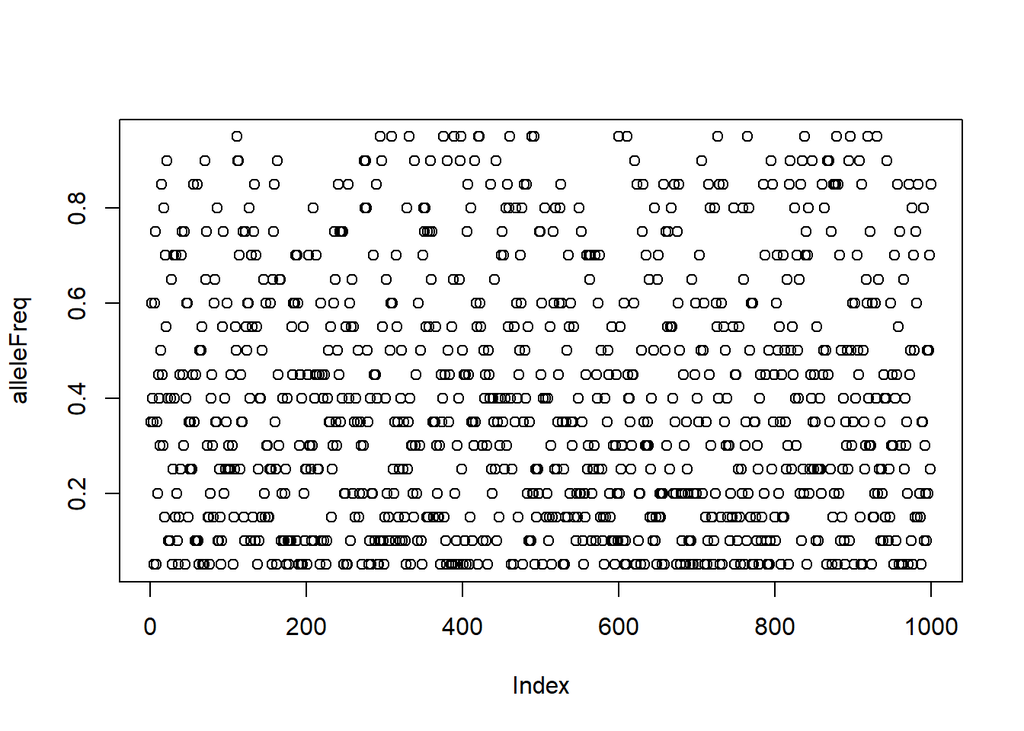

```r
# Allele frequency
alleleFreq = colMeans(popHaplo)

plot(alleleFreq)
```

#### Non-additive effects: **Trait with additive and dominance effects**

```r
# Global simulation parameters from founder genomes.
SP = SimParam$new(founderGenomes)

# Additive trait
SP$addTraitAD(nQtlPerChr = 15, # Number of QTLs controlling the trait per chromosome
              # nQtlPerChr = c(15, 5), # Alternative: QTL effect by chromosome
              mean = 10,
              var = 10,
              meanDD = 0.1, # dominance degree - it varies from 0-1 (meaning no-dominance and codominance)
              varDD = 0.2) # Variance for the degree of dominance

# QTL effects for additive effects
SP$traits[[1]]@addEff
```

```
##   [1]  0.780247707 -0.487353940 -1.269906012 -1.247051299 -0.091761574
##   [6]  0.016169526  0.173178212  0.101523270  0.397094053  0.100332951
##  [11]  0.384119011  0.638624110 -0.019663702  0.301857468  0.137373422
##  [16] -0.466677625 -0.092614135  0.592090521  0.017921355 -0.398389099
##  [21] -0.586636164  1.000756946  0.616929715 -0.305046386  1.096198731
##  [26]  1.350829459  0.104904596  1.000304763 -1.163159220 -0.281195582
##  [31] -0.804928657  0.022754169 -0.087130664 -1.037365222  0.896845586
##  [36] -0.520856804 -0.739784095 -0.248129122  0.072579396 -0.025582275
##  [41] -1.211977842  0.007393246  0.298610274 -0.886251259 -0.551403603
##  [46]  0.072123697  0.238040265  1.380606701  0.273832163 -1.102504053
##  [51] -0.576032632  0.152240353 -0.453234155  0.234427949  0.534416476
##  [56]  0.036658791 -1.493351563 -0.421085550 -0.662326823 -0.086441506
##  [61] -1.170767932 -1.576099996 -0.737600911 -1.253461589  0.158816988
##  [66]  0.032846948  0.422011837  0.217867587 -0.816754632  0.800623540
##  [71] -0.789661210  0.358829573  0.738363608 -0.222951733  0.057174988
##  [76] -0.390316767 -1.667055002 -0.380218481 -0.947630240 -0.891229503
##  [81]  0.422954621 -0.015042713 -0.710260401  0.609043438  0.377300540
##  [86] -0.018065644 -0.575593845 -0.266469383  0.052644821  0.466636177
##  [91]  0.566396558  0.547807710 -0.459149470 -1.286182699 -0.723823170
##  [96]  0.661168962  0.192130177 -0.465964987  0.190600821  0.426614256
## [101]  0.190210466  0.156338546 -0.872564890  0.017843902 -0.184812679
## [106]  0.271078204 -0.345839164 -0.017273015 -0.371467191  0.313561358
## [111]  0.169723095 -0.844400040 -1.109410339  0.478950223  0.403918351
## [116] -0.303570271 -0.891425680 -0.105031953 -0.551836634  1.272935118
## [121] -0.572124950 -1.791143010 -0.489568804  2.093681189 -0.786161152
## [126]  0.603276356 -2.093276363 -0.450421559 -0.144041305 -0.840477612
## [131] -0.420219277 -0.270175012 -0.901040642  1.129621204 -0.178913038
## [136]  0.112990912 -0.024300719  0.045314340 -0.142011046  0.700562633
## [141] -0.620216026  0.422033774 -0.722370969 -0.572991831 -0.343346060
## [146]  1.741171667  0.171582304 -0.284523491 -0.148360424 -0.679703969
```

```r
# QTL effects for dominance effects
SP$traits[[1]]@domEff
```

```
##   [1]  0.047639035  0.016254900  1.181561166 -0.416166407 -0.031928687
##   [6] -0.013858072  0.035124053 -0.040796749  0.057186296  0.003448641
##  [11]  0.004035300 -0.443363169 -0.008013378 -0.090494433  0.045421450
##  [16]  0.243038148 -0.095987437  0.081275749 -0.008572046 -0.111449185
##  [21] -0.129754765 -0.090282567 -0.376269648  0.255386957 -0.453239651
##  [26]  0.321909357  0.035592163 -0.401475139  0.560430954  0.051147076
##  [31]  0.343639605  0.007781657  0.073663669 -0.294975764 -0.180983596
##  [36] -0.269489323 -0.284546148 -0.134149895 -0.004476229  0.020436090
##  [41]  0.123039736  0.003239567 -0.036258436  0.767782278 -0.169264244
##  [46] -0.059277814  0.004967971  0.188372672 -0.091958476  0.598651435
##  [51]  0.439159827  0.146019088  0.232309211  0.040446095  0.165686816
##  [56]  0.003406726 -0.154512427 -0.058619047  0.160020183 -0.013991377
##  [61]  0.849471492  0.795918738 -0.080137216  0.085989027  0.046445714
##  [66]  0.007794452  0.338758666 -0.068364527 -0.251119620  0.028846377
##  [71] -0.106491268  0.083481233 -0.133946972  0.051516088  0.004881393
##  [76]  0.166808487 -0.081045175  0.204332069  0.778376863 -0.110171342
##  [81]  0.057751770 -0.003616832 -0.485160409  0.498333035 -0.195638242
##  [86]  0.017027778 -0.024922204 -0.064339284 -0.023448470  0.120825884
##  [91] -0.397564542 -0.499314669 -0.328624365  0.997063605  0.168369215
##  [96]  0.118323698  0.132396649 -0.047506411 -0.019464603 -0.286125284
## [101] -0.120118391 -0.105562807  0.573272405 -0.002324469 -0.035613788
## [106]  0.139463299  0.233265139  0.011146124 -0.229300715  0.030543535
## [111]  0.086583862  0.186401233  0.074273123  0.427488403  0.041393429
## [116] -0.135358676  0.610959799  0.009200015 -0.129708213  0.116261562
## [121] -0.005277494 -0.198139051  0.163003026  1.208433509  0.198359495
## [126] -0.256344955  0.986646393 -0.048936909  0.108401325  0.232356772
## [131]  0.328828032 -0.212588911 -0.018137022  0.006078439  0.027008828
## [136]  0.035478605  0.005172285  0.009565332  0.046914505 -0.010446415
## [141] -0.043787964 -0.110442409 -0.167216554  0.485567690  0.104465161
## [146]  0.148811163  0.081916413  0.104149284 -0.037432931  0.021733648
```

So, we can create traits with the combinations of those effects (assuming that all of them as, at least, additive) using the **ADGE** framework, as it follows:

```r
# Traits that can be created in AlphaSimR:
SP$addTraitA()
SP$addTraitAD()
SP$addTraitADG()
SP$addTraitADEG()
SP$addTraitAG()
SP$addTraitAE()
SP$addTraitAEG()
```

## Multi-trait framework

The `AlphaSimR` package allows to simulate a set of traits for the individuals. For such, two strategies may be used.

The first strategy is to set all traits at once (using `$addTrait`). In this option, a correlation matrix between each pair of traits, for each effect, should be added, as follows:

```r
rm(list=ls())
# Founder genome
founderGenomes = AlphaSimR::quickHaplo(nInd = 3, # LD, p=q=0.5, haplotypes from 0,1.
                         nChr = 3,
                         segSites = 100)

# From the base population
SP = SimParam$new(founderGenomes)

# Alternative one - Setting the correlation between traits (Additive trait)
SP$addTraitA(nQtlPerChr = 20,
             mean = c(0, 10),
             var = c(0.5, 2),
             corA = matrix(c(1.0, 0.5,
                             0.5, 1.0), nrow = 2))


# QTL effects for trait one
SP$traits[[1]]@addEff
```

```
##  [1]  0.2290251069  0.2441651222  0.3029507664  0.3077077461 -0.2972007612
##  [6]  0.5173174254  0.2508114831 -0.2007550496  0.0457774633  0.1905144136
## [11]  0.1466971199  0.1916791879  0.1188953808 -0.0955399642  0.0939311457
## [16]  0.1444396536 -0.2117420477 -0.2145416350 -0.4601159079  0.1549942832
## [21]  0.5817058591 -0.1107348664  0.0638352879 -0.0872512301 -0.0904934525
## [26] -0.3789265715 -0.3715813493 -0.2668805669  0.1418988183 -0.2702105328
## [31]  0.1271771921 -0.2237840918  0.0085073276 -0.2088390327 -0.1883229842
## [36]  0.1348169503 -0.2781722211  0.0470201019  0.0577347300 -0.1468260158
## [41]  0.0967544412 -0.0008380173  0.0270439441  0.1765114366 -0.2010104777
## [46]  0.0868925834  0.1816365692 -0.1884773228 -0.0941057927 -0.2356188465
## [51] -0.0332832184  0.1004036229  0.0742151686 -0.2044750533  0.1501508308
## [56]  0.1089308092 -0.1387989256  0.4798144083  0.2881120628  0.2872272680
```

```r
# QTL effects for trait two
SP$traits[[2]]@addEff
```

```
##  [1] -0.034815372 -0.031756648  0.033999906  0.785947336 -0.146362306
##  [6] -0.133358572  0.285649151 -0.153070063 -0.110048907 -0.417160812
## [11]  0.348114170  0.010502804  0.326338202 -0.479021971 -0.074231811
## [16]  0.403896146 -0.277967623 -0.398587988 -0.825472352  0.836460164
## [21]  0.342178719 -0.346725813 -0.003337369  0.035384180  0.073644914
## [26] -1.011656060  0.186072877 -0.411544304  0.115894375 -0.041581654
## [31]  0.065793762  0.107345411  0.157368712 -0.319349576  0.047018515
## [36] -0.008459182 -0.470528513  0.289086746 -0.105934830 -0.022827164
## [41]  0.392217921 -0.137367713 -0.150171033 -0.300671270 -0.228526801
## [46]  0.194717214  0.339439314 -0.312254829  0.165703012 -0.193181400
## [51]  0.185216263  0.004676330 -0.025210059 -0.850662717  0.643995431
## [56]  0.459467610 -0.717636845  0.113203349  0.493948156  0.850083171
```

A second strategy in a multi-trait framework is to add each trait individually. In this case, we do not need to add the information of correlation between them. Another positive aspect of this second strategy is the possibility of setting a different number of QTLs controlling each trait simulated.

```r
# From the base population
SP = SimParam$new(founderGenomes)

# Alternative two - One trait at a time

# Trait one
SP$addTraitA(nQtlPerChr = 20,
             mean = 0,
             var = 0.5)

# Trait two
SP$addTraitA(nQtlPerChr = 5,
             mean = 100,
             var = 20)

# QTL effects for trait one
SP$traits[[1]]@addEff
```

```
##  [1] -0.32770099 -0.07223123 -0.42208626 -0.05465270 -0.01272842  0.73556171
##  [7]  0.09970047 -0.73730769 -0.22961957 -0.08753253  0.15112800 -0.15160323
## [13] -0.07291887  0.59192188 -0.20349971  0.67519737  0.09815017 -0.18705538
## [19]  0.10506299 -0.17366900 -0.02899719  0.15228530 -0.57771983 -0.09313978
## [25]  0.09134781  0.31440722  0.34588836  0.57655633  0.28074450  0.05297949
## [31]  0.23159002  0.04240052  0.02602039  0.30204222  0.21752080 -0.37891815
## [37]  0.29685021 -0.52981112 -0.28456329  0.02856641  0.95158188  0.03593571
## [43] -0.04098482 -0.44223218 -0.12280024  0.41138331 -0.32340035  0.79130579
## [49]  0.57229674  0.20561058  0.12645046  0.36799576  0.10128746 -0.12259787
## [55]  0.91029927 -0.03982485 -0.29831049 -0.42644228  0.20993957 -0.52476795
```

```r
# QTL effects for trait two
SP$traits[[2]]@addEff
```

```
##  [1] -1.09411493 -0.43592529 -0.07113493  0.59293637  1.47692874 -0.50789459
##  [7] -0.73739642 -1.64366392 -2.35271610  1.04388016  0.35536704  0.89803573
## [13]  0.05229721 -0.73050826  1.66183979
```

## Split argument

In breeding programs, such as maize, heterosis is harnessed by exploiting the crosses between heterotic groups. Usually, two distinct groups are used (*i*.*e*., maize dent and flint germplasm pools). The genetic divergence of these two pools is explained by their historic geographical separation and adaptation to different environments. It has undergone changes in the population structure and history of the base population.

For simulations that involve population separation in terms of generations, the **AlphaSimR** package offers the split argument in the `runMacs()` function. It represents an optional historic population split in terms of generations ago.

Below, we will simulate three different base genomes. The first one will use the default value (NULL) for the split argument. The second and third genomes will be split 10 and 50 generations ago, respectively. We will examine the base genome genotypes and explore them through a principal component analysis (PCA).

```r
rm(list=ls())
#------------------- Founder genome with no split
founderGenomes = runMacs(nInd = 200,
                         nChr = 5,
                         segSites = 100,
                         species = "MAIZE",
                         ploidy = 2,
                         split = NULL)

# From the base population
SP = SimParam$new(founderGenomes)

# Creating individuals/population
basePop = newPop(founderGenomes)

# Check the genotypes
popGeno = pullSegSiteGeno(basePop)

# PCA
pca_noSplit = prcomp(popGeno)

#------------------- Founder genome with split equals to 10
founderGenomes = runMacs(nInd = 200,
                         nChr = 5,
                         segSites = 100,
                         species = "MAIZE",
                         ploidy = 2,
                         split = 10)

# From the base population
SP = SimParam$new(founderGenomes)

# Creating individuals/population
basePop = newPop(founderGenomes)

# Check the genotypes
popGeno_10 = pullSegSiteGeno(basePop)

# PCA
pca_Split10 = prcomp(popGeno_10)


#------------------- Founder genome with split equals to 50
founderGenomes = runMacs(nInd = 200,
                         nChr = 5,
                         segSites = 100,
                         species = "MAIZE",
                         ploidy = 2,
                         split = 50)

# From the base population
SP = SimParam$new(founderGenomes)

# Creating individuals/population
basePop = newPop(founderGenomes)

# Check the genotypes
popGeno_50 = pullSegSiteGeno(basePop)

# PCA
pca_Split50 = prcomp(popGeno_50)
```

Plotting the PCA from each base population created.

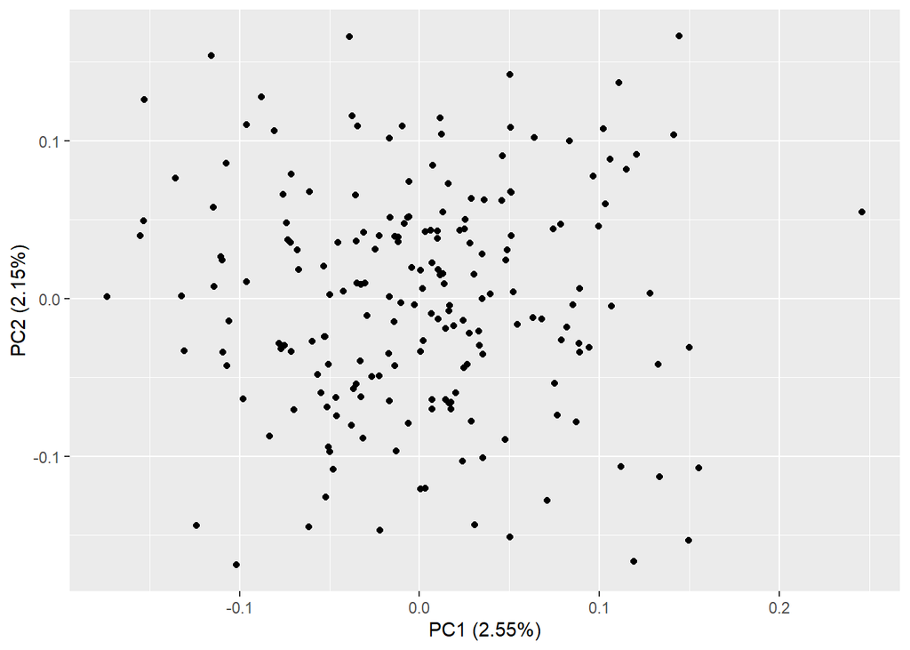

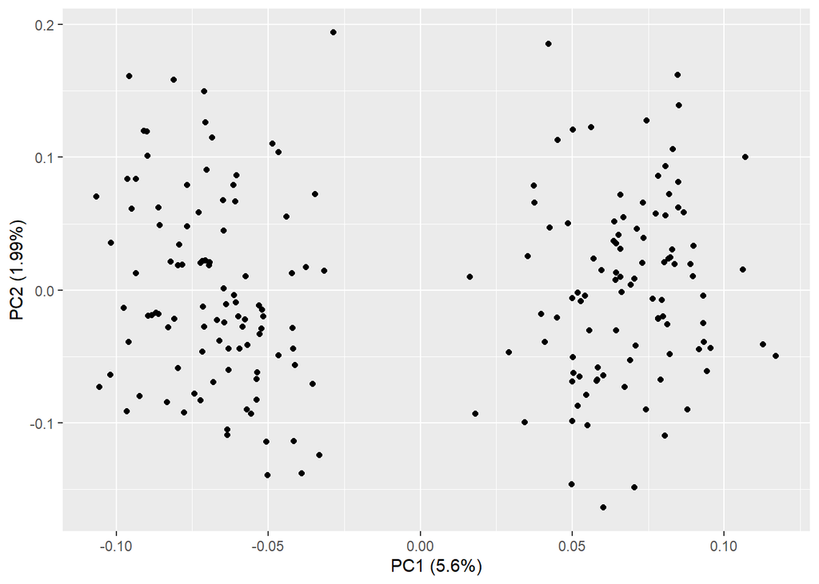

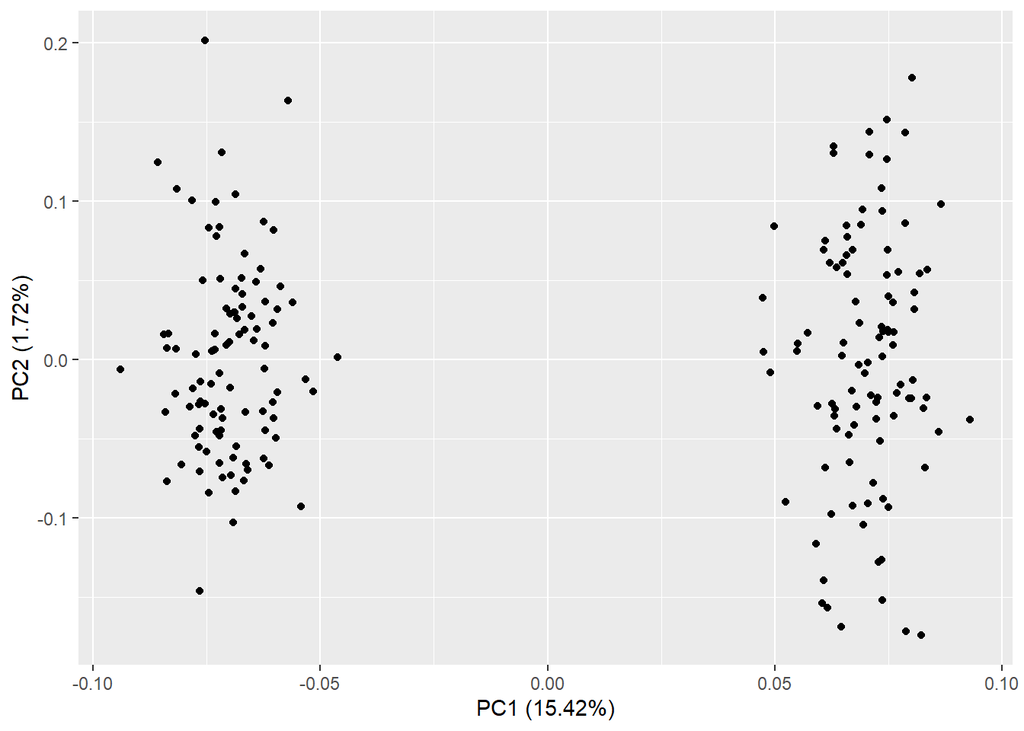

```r
# Plotting the PCA
library(ggfortify)
# Plot
par(mar = c(1, 3, .1, .1))
autoplot(pca_noSplit, data = popGeno)
autoplot(pca_Split10, data = popGeno_10)
autoplot(pca_Split50, data = popGeno_50)
```

## References

Chen, Gary K, Paul Marjoram, and Jeffrey D Wall. 2009. “Fast and Flexible Simulation of DNA Sequence Data.” *Genome Research* 19 (1): 136–42.

Gaynor, R Chris, Gregor Gorjanc, and John M Hickey. 2021. “AlphaSimR: An r Package for Breeding Program Simulations.” *G3* 11 (2): jkaa017.

[^1]: Post doc, University of Florida, deamorimpeixotom@ufl.edu